# The attentive online reading: do eye movement modeling examples enhance navigation and evaluation of multiple documents in English (L2)?

# 1 Preliminary Analyses

## 1.1 Outliers Detection and Replacement

Individual fixations that lasted two standart deviations above or below each participant fixation duration mean were considered outliers and were replaced by the participant fixation duration median(see SALMERÓN; DELGADO; MASON, 2020, p. 1045). Outliers represented 4.56% of the durations.

## 1.2 Tests of Normality and Data Transformation

Figure 1 shows the frequency distributions of the time variables used in the study. All distributions have skewness values higher than 0.5, being right-skewed, as it is commonly observed with time variables. The variables were log-transformed to be better approximated to a normal distribution. The log-transformed variables are shown in Figure 2 with their theoretical probability distributions. Transformation resulted in improved skewness values for two of the four variables, namely, total fixation duration on serp and total fixation duration on source features. Thus, log-transformed variables were used for these two variables.

(see SALMERÓN; DELGADO; MASON, 2020, p. 1047)

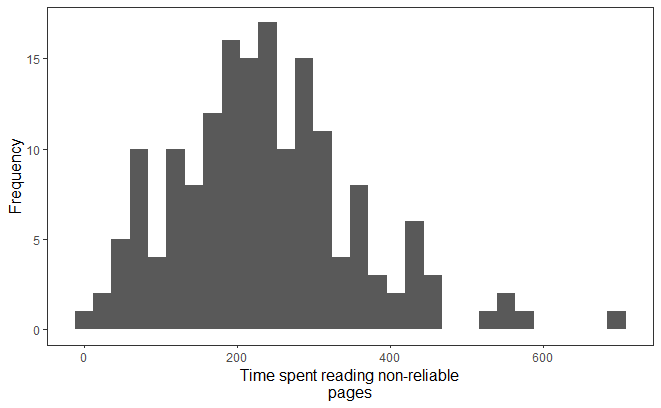

*Figure 1*. Histograms of time variables

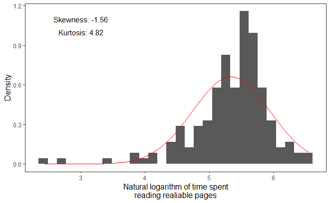

*Figure 2*. Histograms of transformed time variables with theoretical probability distributions

# 2 Main Analysis

## 2.1 Research Questions 1a and 1b

To answer the research questions RQ1a and RQ1b, two linear models were fit: the first one was a multiple linear regression model with the natural logarithm of fixation duration on SERP as response and Group (two levels: EMME and VIDEO), L2 level, and self-perceived strategic behavior as predictors; the second one was a mixed-effects model with total fixation duration on source features, on reliable and non-reliable pages, as response, and, Group and Reliability as predictors, and L2 level and self-perceived strategic behavior as mediators, with random intercepts for participants.

```r
# MEDIATION ANALYSIS
# Total effect for RQ1
rq1_total = reliable_nonreliable %>%
  group_by(Participant, Reliability) %>%
  summarise(EventDuration = mean(EventDuration)) %>%
  mutate(Group = ifelse(str_starts(Participant, 'EMME'), 'EMME', 'VIDEO') %>% as_factor()) %>%
  lmer(EventDuration ~ Group + (1|Participant), data = .)
```

## 2.2 Research Questions 2a, 2b and 2c

To answer the reserch questions RQ2a, RQ2b, and RQ2c, three linear models were fit: the first with the argumentation scores as response and Group, English level, Fixation duration on SERP and fixation duration on source features as predictors; the second model with smt scores as response and Group, English level, Fixation duration on SERP and fixation duration on source features as predictors; and the third model, a mixed-effects model, with scores on the pre and post tests as response, Group, English level, Fixation duration on SERP, Fixation duration on source features, and moment (pre and post) as predictors, and random intercepts for participants.

[output not shown]

### 2.2.2 Figure 6

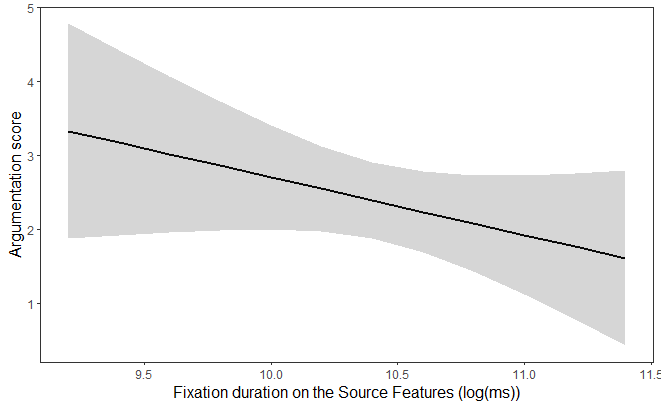

*Figure 6*. *Argumentation score predicted by Fixation duraton on the Source Features*

### 2.2.3 Figure 7

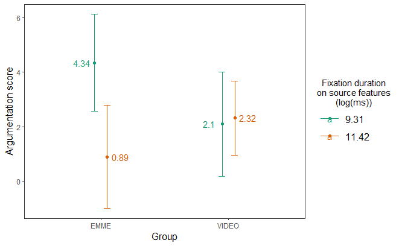

*Figure 7*. Interaction between Group and Fixation duration on source features

### 2.2.4 Figure 8

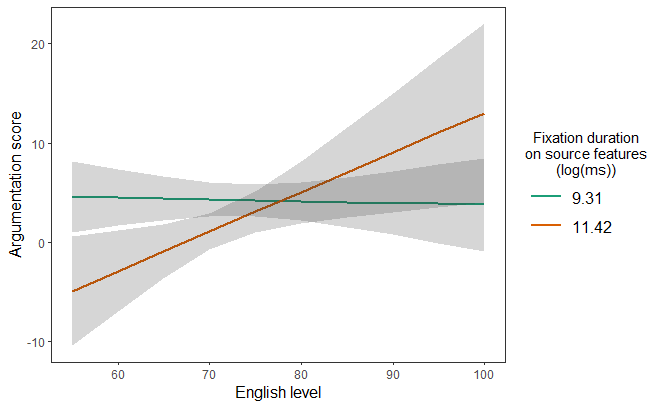

*Figure 8*. Interaction between English level and Fixation duration on source features

### 2.2.5 Figure 9

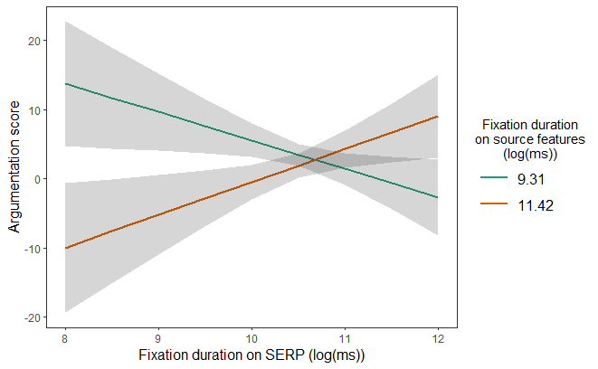

*Figure 9*. Interaction between Fixation duration on SERP and Fixation duration on source features

### 2.2.6 Figure 10

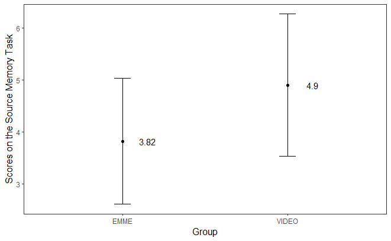

*Figure 10*. Scores on the Source Memory Task predicted by Group

### 2.2.7 Figure 11

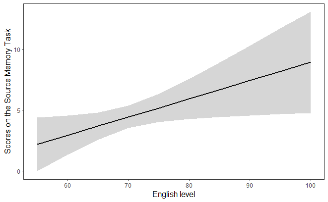

*Figure 11*. Scores on the Source Memory Task predicted by English level

### 2.2.8 Figure 12

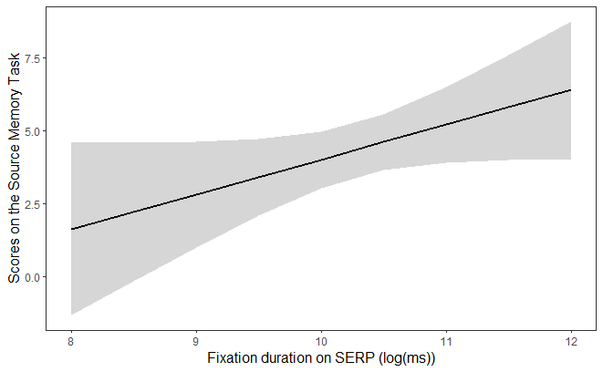

*Figure 12*. Scores on the Source Memory Task predicted by Fixation duration on SERP

### 2.2.9 Figure 13

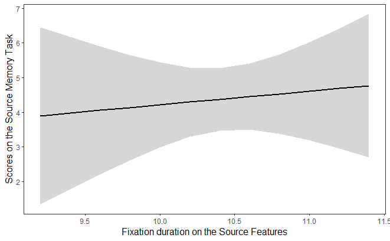

*Figure 13*. Scores on the Source Memory Task predicted by Fixation duration on the Source Features

### 2.2.10 Figure 14

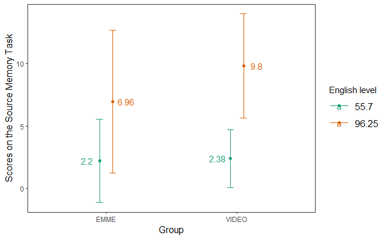

*Figure 14*. Interaction between Group and English level

### 2.2.11 Figure 15

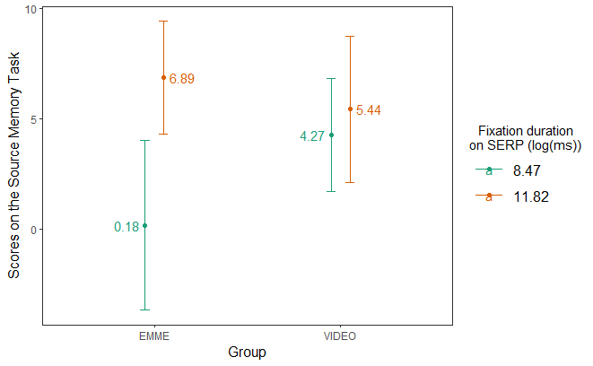

*Figure 15*. Interaction between Group and Fixation duration on SERP

### 2.2.12 Figure 16

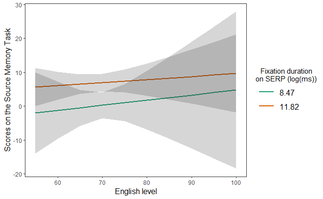

*Figure 16*. Interaction between English level and Fixation duration on SERP

### 2.2.13 Figure 17

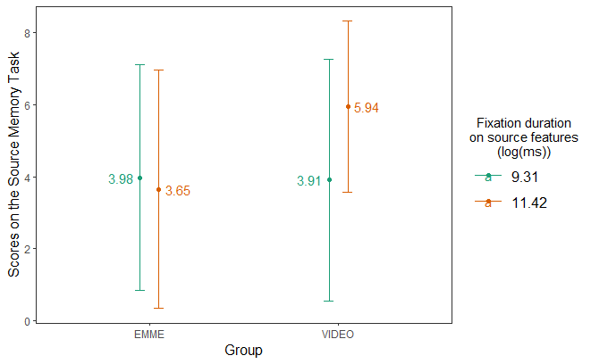

*Figure 17*. Interaction between Group and Fixation duration on source features

### 2.2.14 Figure 18

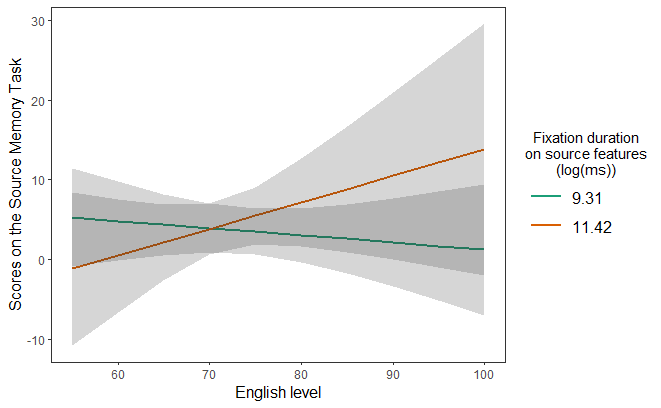

*Figure 18*. Interaction between English level and Fixation duration on source features

### 2.2.15 Figure 19

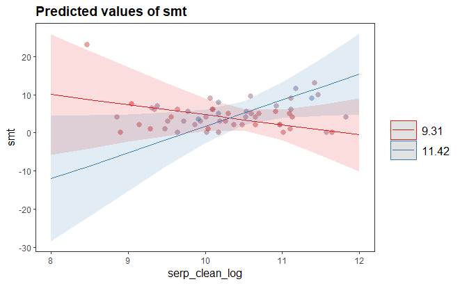

*Figure 19*. Interaction between Fixation duration on SERP and Fixation duration on source features

### 2.2.16 Figure 20

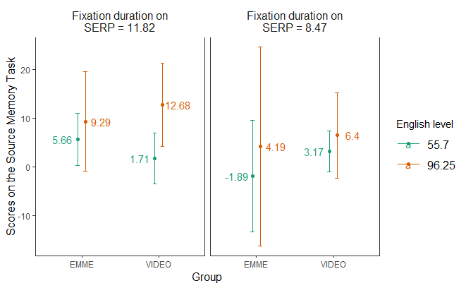

*Figure 20*. Interaction between Group, English level and Fixation duration on SERP

### 2.2.17 Figure 21

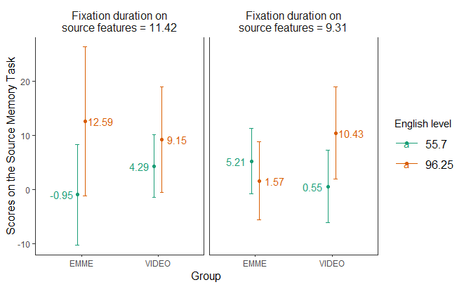

### 2.2.18 Figure 22

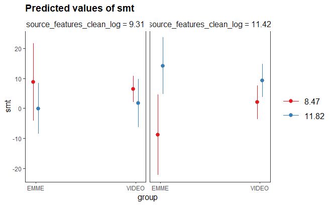

### 2.2.19 Figure 23

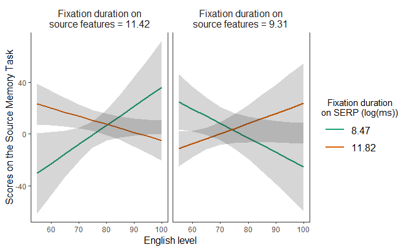

### 2.2.20 References

SALMERÓN, L.; DELGADO, P.; MASON, L. Using eye-movement modelling examples to improve critical reading of multiple webpages on a conflicting topic. **Journal of Computer Assisted Learning**, vol. 36, no. 6, p. 1038–1051, 2020. https://doi.org/10.1111/jcal.12458.